# Lab 08 - Trees and Random Forests

# Learning goals

- Perform classification and regression with tree-based methods in Python
- Use cost-complexity pruning to select optimal tree size
- Compare the performance of pruned trees and random forests
- Examine variable importance

# Lab description

##### Download lab `.qmd` [here](https://github.com/JSC370/JSC370-2026/blob/main/labs/lab8/lab08-trees-boosting.qmd)

For this lab we will be working with the `cps_clean.csv` dataset.

The Current Population Survey (CPS) has been run from 1962 to the present, and it covers detailed labor force, income, and demographic data. We are using the Annual Social and Economic Supplement (ASEC) from 2020-2025. Source: [IPUMS CPS](https://cps.ipums.org/cps/).

# Deliverables

Questions 1-4 answered, qmd and html uploaded to Quercus

## Data dictionary for cleaned dataset (`cps_clean.csv`)

| Variable | Description | Type | Values |
| --- | --- | --- | --- |
| `AGE` | Age in years | Numeric | 0-99 |
| `female` | Sex | Binary | 0 = Male, 1 = Female |
| `married` | Marital status | Binary | 0 = Not married, 1 = Married |
| `educ_cat` | Education level | Ordinal | 1 = Less than HS, 2 = HS diploma, 3 = Some college/Associates, 4 = Bachelor’s, 5 = Graduate |
| `faminc_cat` | Family income bracket | Ordinal | 1 = Low (<$40k), 2 = Middle ($40k-$100k), 3 = High ($100k+) |
| `metro_binary` | Metropolitan area | Binary | 0 = Non-metro, 1 = Metro |
| `race_cat` | Race | Categorical | White, Black, Asian, Other |
| `us_citizen` | US citizenship | Binary | 0 = Not a citizen, 1 = US citizen (born or naturalized) |
| `has_children` | Has children in household | Binary | 0 = No, 1 = Yes |
| `insured` | Health insurance last year | Binary | 0 = No, 1 = Yes |
| `OCC` | Occupation code | Numeric | 4-digit Census occupation codes |
| `IND` | Industry code | Numeric | 4-digit Census industry codes |
| `INCWAGE` | Wage and salary income | Numeric | Dollar amount |
| `FIRMSIZE` | Employer firm size | Ordinal | 0 = NIU, 1 = Under 10, 2 = 10-24, 5 = 25-99, 7 = 100-499, 8 = 500-999, 9 = 1000+ |
| `NCHILD` | Number of own children | Numeric | 0-9 |
| `YEAR` | Survey year | Numeric | 2020-2025 |
| `STATEFIP` | State FIPS code | Numeric | 1-56 |
| `worker_cat` | Worker category | Categorical | Unemployed, Part-time, Private for-profit, Private nonprofit, Government, Self-employed |

### Setup

We will use the following Python libraries: `scikit-learn` (trees, random forest), `pandas`, `numpy`, `plotnine`, `matplotlib` (for tree plots).

### Load packages and data

```python
import pandas as pd
import numpy as np
import matplotlib.pyplot as plt
from plotnine import *
from sklearn.model_selection import train_test_split
from sklearn.tree import DecisionTreeClassifier, DecisionTreeRegressor, plot_tree
from sklearn.ensemble import RandomForestClassifier, RandomForestRegressor
from sklearn.metrics import accuracy_score, mean_squared_error, r2_score, confusion_matrix, ConfusionMatrixDisplay
import warnings
warnings.filterwarnings('ignore')

cps = pd.read_csv("https://raw.githubusercontent.com/JSC370/JSC370-2026/main/data/cps_clean.csv")
cps = cps[cps['YEAR'].isin([2024, 2025])]
print(f"Dataset size (2024-2025): {cps.shape[0]} rows")
cps.head()
```

```
Dataset size (2024-2025): 98270 rows
```

|  | AGE | female | married | educ_cat | faminc_cat | metro_binary | race_cat | us_citizen | has_children | insured | OCC | IND | INCWAGE | FIRMSIZE | NCHILD | YEAR | STATEFIP | worker_cat |
| --- | --- | --- | --- | --- | --- | --- | --- | --- | --- | --- | --- | --- | --- | --- | --- | --- | --- | --- |
| 231802 | 63 | 0 | 1 | 2 | 3 | 0 | White | 1 | 1 | 1 | 6130 | 270 | 61729 | 2 | 1 | 2024 | 23 | Self-employed |
| 231803 | 57 | 0 | 1 | 2 | 2 | 0 | White | 1 | 1 | 1 | 4220 | 4972 | 43000 | 9 | 1 | 2024 | 23 | Private for-profit |
| 231804 | 57 | 1 | 1 | 2 | 2 | 0 | White | 1 | 1 | 1 | 9005 | 6380 | 25000 | 9 | 1 | 2024 | 23 | Part-time |
| 231805 | 23 | 0 | 0 | 2 | 2 | 0 | White | 1 | 0 | 1 | 9620 | 6170 | 20000 | 5 | 0 | 2024 | 23 | Private for-profit |
| 231806 | 58 | 0 | 0 | 3 | 1 | 0 | White | 1 | 0 | 1 | 6355 | 1870 | 80000 | 8 | 0 | 2024 | 23 | Private for-profit |

### Data preparation

We will use the following features as predictors: `AGE`, `female`, `married`, `educ_cat`, `faminc_cat`, `metro_binary`, `race_cat`, `us_citizen`, `has_children`, `insured`, `FIRMSIZE`, `NCHILD`.

First let’s encode race into dummy (binary) variables.

```python
cps_encoded = pd.get_dummies(cps, columns=['race_cat'], drop_first=True)

feature_cols = ['AGE', 'female', 'married', 'educ_cat', 'faminc_cat',
                'metro_binary', 'us_citizen', 'has_children', 'insured',
                'FIRMSIZE', 'NCHILD',
                'race_cat_Black', 'race_cat_Other', 'race_cat_White']

cps_encoded.head()
```

|  | AGE | female | married | educ_cat | faminc_cat | metro_binary | us_citizen | has_children | insured | OCC | IND | INCWAGE | FIRMSIZE | NCHILD | YEAR | STATEFIP | worker_cat | race_cat_Black | race_cat_Other | race_cat_White |
| --- | --- | --- | --- | --- | --- | --- | --- | --- | --- | --- | --- | --- | --- | --- | --- | --- | --- | --- | --- | --- |
| 231802 | 63 | 0 | 1 | 2 | 3 | 0 | 1 | 1 | 1 | 6130 | 270 | 61729 | 2 | 1 | 2024 | 23 | Self-employed | False | False | True |
| 231803 | 57 | 0 | 1 | 2 | 2 | 0 | 1 | 1 | 1 | 4220 | 4972 | 43000 | 9 | 1 | 2024 | 23 | Private for-profit | False | False | True |
| 231804 | 57 | 1 | 1 | 2 | 2 | 0 | 1 | 1 | 1 | 9005 | 6380 | 25000 | 9 | 1 | 2024 | 23 | Part-time | False | False | True |
| 231805 | 23 | 0 | 0 | 2 | 2 | 0 | 1 | 0 | 1 | 9620 | 6170 | 20000 | 5 | 0 | 2024 | 23 | Private for-profit | False | False | True |
| 231806 | 58 | 0 | 0 | 3 | 1 | 0 | 1 | 0 | 1 | 6355 | 1870 | 80000 | 8 | 0 | 2024 | 23 | Private for-profit | False | False | True |

## Part 1: Classification — Predicting `worker_cat`

We want to predict worker category (Unemployed, Part-time, Private for-profit, Private nonprofit, Government, Self-employed) using the demographic and economic features listed above.

### Question 1: Classification Trees with Cost-Complexity Pruning

**a)** Split the data into training (70%) and testing (30%) sets using [`train_test_split`](https://scikit-learn.org/stable/modules/generated/sklearn.model_selection.train_test_split.html). Use `random_state=65`. Print the sizes of the training and testing sets, and show the count and proportion of each `worker_cat` category in the training set.

```python
# YOUR CODE HERE
X_class = cps_encoded[feature_cols]
Y_class = cps_encoded['worker_cat']

X_train_c, X_test_c, Y_train_c, Y_test_c = train_test_split(
  X_class, Y_class, test_size=0.30, random_state=65
)

print(f"Training set size: {X_train_c.shape[0]}")
print(f"Testing set size: {X_test_c.shape[0]}")
print(f"\nCount of each worker_cat category in training set:")
train_counts = Y_train_c.value_counts().sort_index()
print(train_counts)
print(f"\nProportions:")
train_props = Y_train_c.value_counts(normalize=True).sort_index()
print(train_props)
```

```
Training set size: 68789
Testing set size: 29481

Count of each worker_cat category in training set:
worker_cat
Government             8045
Part-time             12892
Private for-profit    39993
Self-employed          4733
Unemployed             3126
Name: count, dtype: int64

Proportions:
worker_cat
Government            0.116952
Part-time             0.187414
Private for-profit    0.581387
Self-employed         0.068805
Unemployed            0.045443
Name: proportion, dtype: float64
```

**b)** Fit a full (unpruned) classification tree using [`DecisionTreeClassifier`](https://scikit-learn.org/stable/modules/generated/sklearn.tree.DecisionTreeClassifier.html) with `min_samples_split=20` and `min_samples_leaf=5`. Plot the tree using [`plot_tree`](https://scikit-learn.org/stable/modules/generated/sklearn.tree.plot_tree.html) (hint: use `max_depth=3` for readability). How many leaves does the full tree have?

```
Number of leaves in full tree: 5832
Depth of full tree: 34
```

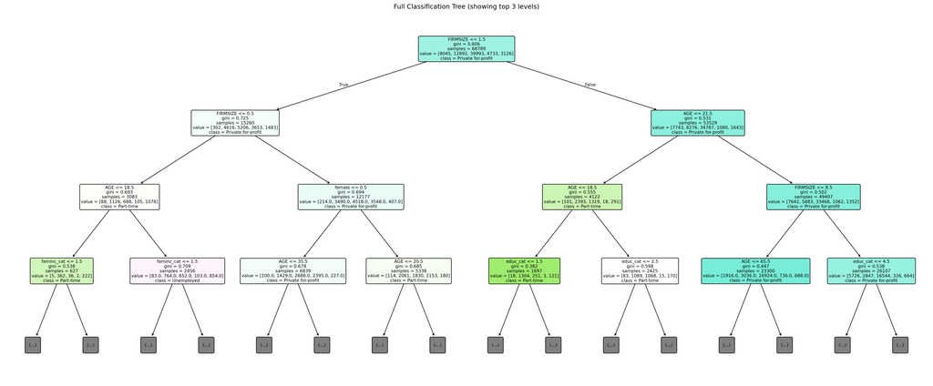

```python
# YOUR CODE HERE
class_labels = sorted(Y_class.unique())

full_tree_c = DecisionTreeClassifier(
  min_samples_split=20,
  min_samples_leaf=5,
  random_state=65
)
full_tree_c.fit(X_train_c, Y_train_c)

print(f"Number of leaves in full tree: {full_tree_c.get_n_leaves()}")
print(f"Depth of full tree: {full_tree_c.get_depth()}")

plt.figure(figsize=(24, 10))
plot_tree(
  full_tree_c,
  feature_names=feature_cols,
  class_names=class_labels,
  filled=True,
  rounded=True,
  max_depth=3,
  fontsize=8
)
plt.title("Full Classification Tree (showing top 3 levels)")
plt.tight_layout()
plt.show()
```

**c)** Use [`cost_complexity_pruning_path`](https://scikit-learn.org/stable/modules/generated/sklearn.tree.DecisionTreeClassifier.html#sklearn.tree.DecisionTreeClassifier.cost_complexity_pruning_path) to explore how `ccp_alpha` affects tree size. Plot the number of leaves as a function of `ccp_alpha`. Choose a `ccp_alpha` that produces a reasonably small tree (e.g., 5-15 leaves).

```python
path = full_tree_c.cost_complexity_pruning_path(X_train_c, Y_train_c)
ccp_alphas = path.ccp_alphas
ccp_alphas_pos = ccp_alphas[ccp_alphas > 0]

# Subsample ~25 log-spaced alpha values (fitting a tree for every alpha is too slow)
# Log-spacing captures the interesting range where tree size changes most
log_alphas = np.logspace(
    np.log10(ccp_alphas_pos.min()),
    np.log10(ccp_alphas_pos.max()),
    num=25
)
log_alphas = np.unique(np.concatenate(([0.0], log_alphas)))

# Compute number of leaves for each sampled alpha
n_leaves = []
for alpha in log_alphas:
    tree = DecisionTreeClassifier(
        min_samples_split=20,
        min_samples_leaf=5,
        ccp_alpha=alpha,
        random_state=65
    )
    tree.fit(X_train_c, Y_train_c)
    n_leaves.append(tree.get_n_leaves())

ccp_df = pd.DataFrame({'ccp_alpha': log_alphas, 'n_leaves': n_leaves})
print(ccp_df)
```

```
       ccp_alpha  n_leaves
0   0.000000e+00      5832
1   3.607248e-08      5831
2   6.382565e-08      5829
3   1.129314e-07      5826
4   1.998176e-07      5822
5   3.535519e-07      5816
6   6.255650e-07      5802
7   1.106858e-06      5745
8   1.958443e-06      5623
9   3.465216e-06      5349
10  6.131258e-06      4736
11  1.084848e-05      3441
12  1.919500e-05      1539
13  3.396311e-05       432
14  6.009340e-05       140
15  1.063276e-04        86
16  1.881332e-04        43
17  3.328777e-04        31
18  5.889846e-04        21
19  1.042133e-03        15
20  1.843922e-03         9
21  3.262585e-03         5
22  5.772729e-03         4
23  1.021411e-02         3
24  1.807256e-02         3
25  3.197710e-02         1
```

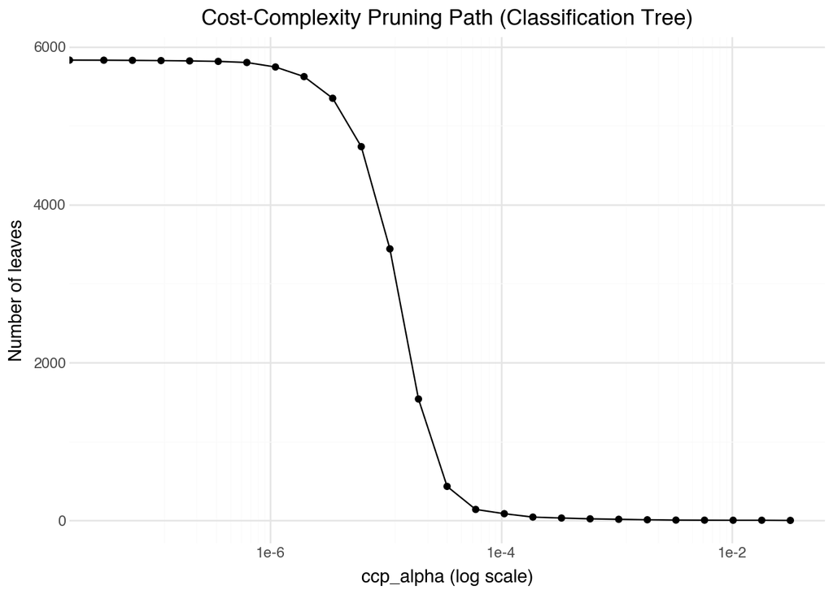

```python
# Plot number of leaves vs ccp_alpha
(
  ggplot(ccp_df, aes(x='ccp_alpha', y='n_leaves')) +
  geom_line() +
  geom_point() +
  scale_x_log10() +
  labs(
    title='Cost-Complexity Pruning Path (Classification Tree)',
    x='ccp_alpha (log scale)',
    y='Number of leaves'
  ) +
  theme_minimal()
)
```

```python
# Choose a ccp_alpha that gives a small, interpretable tree
# Look at the table above and pick one with ~5-15 leaves
optimal_ccp_alpha_c = 1.843922e-03
expected_leaves_c = int(
    ccp_df.loc[np.isclose(ccp_df['ccp_alpha'], optimal_ccp_alpha_c), 'n_leaves'].iloc[0]
)
print(f"Chosen ccp_alpha: {optimal_ccp_alpha_c}")
print(f"Expected number of leaves: {expected_leaves_c}")
```

```
Chosen ccp_alpha: 0.001843922
Expected number of leaves: 9
```

**d)** Fit a pruned tree using the chosen `ccp_alpha` and plot it. How does the pruned tree compare to the full tree in terms of complexity? Which variables appear most important for splitting?

```
Number of leaves in pruned tree: 9
Depth of pruned tree: 4
```

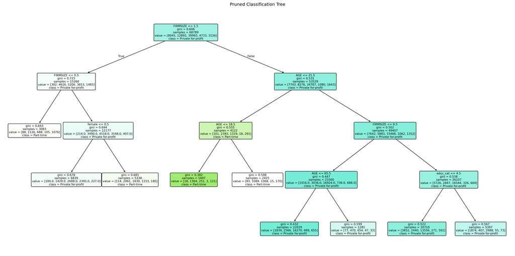

```python
pruned_tree_c = DecisionTreeClassifier(
    min_samples_split=20,
    min_samples_leaf=5,
    ccp_alpha=optimal_ccp_alpha_c,
    random_state=65
)
pruned_tree_c.fit(X_train_c, Y_train_c)

print(f"Number of leaves in pruned tree: {pruned_tree_c.get_n_leaves()}")
print(f"Depth of pruned tree: {pruned_tree_c.get_depth()}")

plt.figure(figsize=(20, 10))
plot_tree(
    pruned_tree_c,
    feature_names=feature_cols,
    class_names=class_labels,
    filled=True,
    rounded=True,
    fontsize=8
)
plt.title("Pruned Classification Tree")
plt.tight_layout()
plt.show()
```

**e)** Compute the test accuracy and test misclassification error of the pruned tree. Also display the [`confusion_matrix`](https://scikit-learn.org/stable/modules/generated/sklearn.metrics.confusion_matrix.html). Which categories are easiest/hardest to predict?

```
Test accuracy (pruned tree): 0.6058817543502595
Test misclassification error (pruned tree): 0.3941182456497405
```

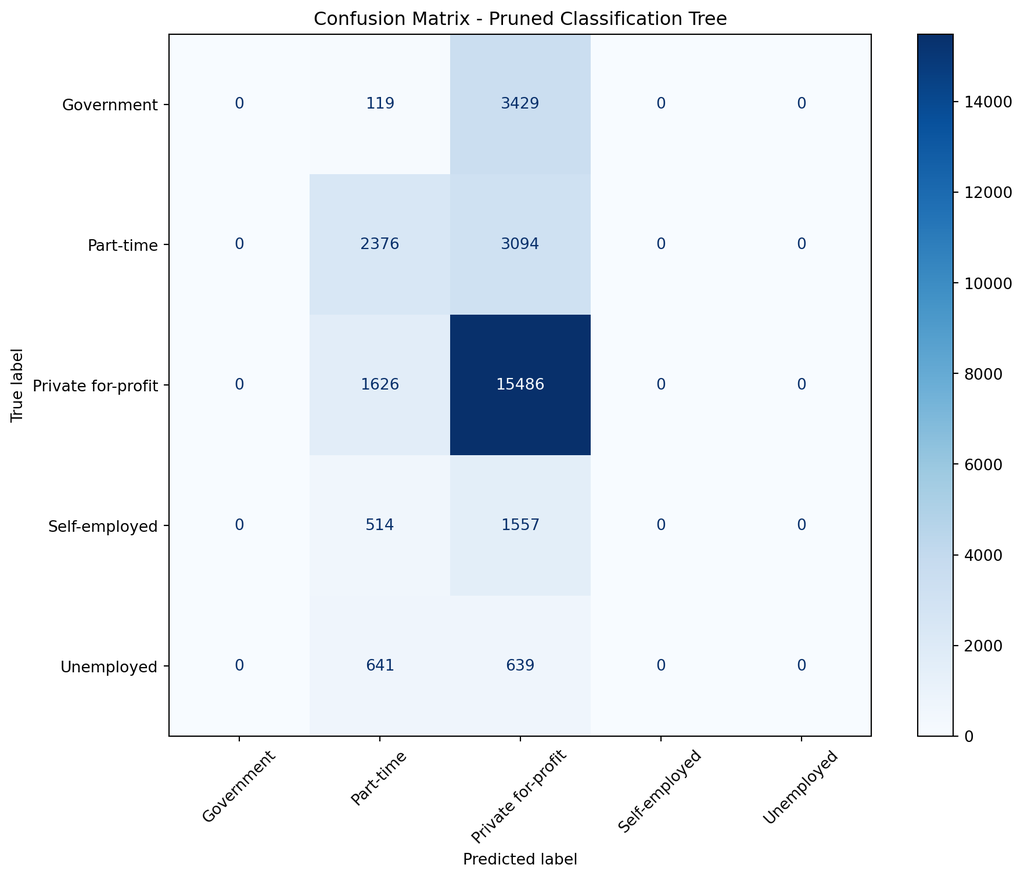

```python
Y_pred_c = pruned_tree_c.predict(X_test_c)
test_acc_c = accuracy_score(Y_test_c, Y_pred_c)
test_error_c = 1 - test_acc_c
print(f"Test accuracy (pruned tree): {test_acc_c}")
print(f"Test misclassification error (pruned tree): {test_error_c}")

# Confusion matrix
cm = confusion_matrix(Y_test_c, Y_pred_c, labels=class_labels)
fig, ax = plt.subplots(figsize=(10, 8))
disp = ConfusionMatrixDisplay(confusion_matrix=cm, display_labels=class_labels)
disp.plot(ax=ax, cmap='Blues', xticks_rotation=45)
plt.title("Confusion Matrix - Pruned Classification Tree")
plt.tight_layout()
plt.show()
```

**Summary:**

According to the confusion matrix, **Private for-profit** is the easiest category to predict by the pruned tree because the model correctly identified 15486 out of 17112 workers, which is 90.50%. However, **Unemployed**, **Self-employed**, and **Government** are the hardest categories to predict because the pruned tree cannot correctly identify any of the workers in these categories.

### Question 2: Classification Random Forest

**a)** Tune the [`RandomForestClassifier`](https://scikit-learn.org/stable/modules/generated/sklearn.ensemble.RandomForestClassifier.html) by trying a few values of `max_features` and `min_samples_leaf` using out of bag (OOB) accuracy. Use `n_estimators=200`, `oob_score=True`, and `random_state=65`. Report the best parameters, then fit the best model with `n_estimators=500` and report OOB and test accuracy. How do these compare to the pruned tree?

*Hint: Try `max_features` in `['sqrt', 1/3, 0.5]` (corresponding to sqrt(p), p/3, and p/2 features per split) and `min_samples_leaf` in `[1, 5, 10]`.*

```python
# print(X_train_c.isnull().sum())
# print(Y_train_c.isnull().sum())
# print(X_test_c.isnull().sum())
# print(Y_test_c.isnull().sum())
```

```python
# Tune: try all combinations of max_features and min_samples_leaf
results = []
for mf in ['sqrt', 1/3, 0.5]:
    for msl in [1, 5, 10]:
        rf = RandomForestClassifier(
            n_estimators=200,
            oob_score=True,
            random_state=65,
            max_features=mf,
            min_samples_leaf=msl
        )
        rf.fit(X_train_c, Y_train_c)
        results.append({
            'max_features': mf, 'min_samples_leaf': msl,
            'oob_accuracy': rf.oob_score_
        })

tune_df = pd.DataFrame(results).sort_values('oob_accuracy', ascending=False)
print(tune_df.to_string(index=False))
```

```
max_features  min_samples_leaf  oob_accuracy
        sqrt                10      0.635494
    0.333333                10      0.634898
         0.5                10      0.634142
    0.333333                 5      0.633343
        sqrt                 5      0.633270
         0.5                 5      0.630755
         0.5                 1      0.573682
    0.333333                 1      0.568230
        sqrt                 1      0.566733
```

```python
# Fit the best model with n_estimators=500
best = tune_df.iloc[0]
print(f"Best parameters: max_features={best['max_features']}, min_samples_leaf={best['min_samples_leaf']}")

rf_class = RandomForestClassifier(
    n_estimators=500,
    oob_score=True,
    random_state=65,
    max_features=best['max_features'],
    min_samples_leaf=int(best['min_samples_leaf'])
)
rf_class.fit(X_train_c, Y_train_c)

y_pred_rf_c = rf_class.predict(X_test_c)
rf_test_acc_c = accuracy_score(Y_test_c, y_pred_rf_c)
rf_oob_acc_c = rf_class.oob_score_

print(f"\nRandom Forest OOB accuracy: {rf_oob_acc_c}")
print(f"Random Forest OOB error: {1 - rf_oob_acc_c}")
print(f"Random Forest test accuracy: {rf_test_acc_c}")
print(f"Random Forest test error: {1 - rf_test_acc_c}")
```

```
Best parameters: max_features=sqrt, min_samples_leaf=10

Random Forest OOB accuracy: 0.6347817238221227
Random Forest OOB error: 0.3652182761778773
Random Forest test accuracy: 0.6344425223024999
Random Forest test error: 0.36555747769750013
```

**b)** Generate a feature importance plot using gain (scikit-learn’s `feature_importances_`). Which are the top 3 most important features? Do these align with the variables that appeared in the pruned classification tree?

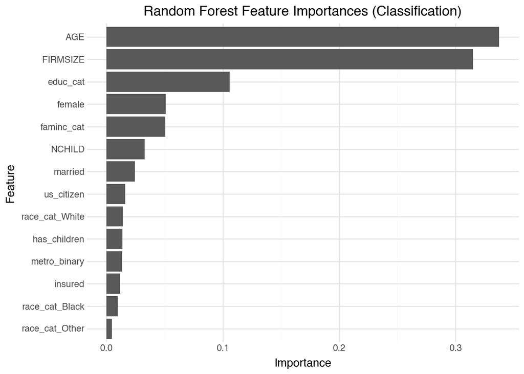

```python
rf_importances_c = rf_class.feature_importances_

imp_df_c = pd.DataFrame({
    'feature': feature_cols,
    'importance': rf_importances_c
}).sort_values('importance')
imp_df_c['feature'] = pd.Categorical(imp_df_c['feature'], categories=imp_df_c['feature'])

(
    ggplot(imp_df_c, aes(x='feature', y='importance')) +
    geom_col() +
    coord_flip() +
    labs(
        title='Random Forest Feature Importances (Classification)',
        x='Feature',
        y='Importance'
    ) +
    theme_minimal()
)
```

**Summary:**

According to the feature importance plot, the top 3 most important features are `AGE`, `FIRMSIZE`, and `educ_cat`. These features align with the variables that appeared in the pruned classification tree. These features align with the variables that appeared in the pruned classification tree.

**c)** Compare the pruned tree and random forest test performance in a summary table. Which model performs better and why might that be?

```python
comparison_c = pd.DataFrame({
    'Model': ['Pruned Decision Tree', 'Random Forest'],
    'Test Accuracy': [test_acc_c, rf_test_acc_c],
    'Test Misclassification Error': [test_error_c, 1 - rf_test_acc_c]
})
print(comparison_c.to_string(index=False))
```

```
               Model  Test Accuracy  Test Misclassification Error
Pruned Decision Tree       0.605882                      0.394118
       Random Forest       0.634443                      0.365557
```

**Summary:**

According to the comparison table, the random forest performs better than the pruned tree on the test set. The random forest has a test accuracy of 63.44% and a test misclassification error of 36.56%, while the pruned tree has a test accuracy of 60.59% and a test misclassification error of 39.41%. This is expected because Random Forests reduce variance by averaging many decorrelated trees. A single decision tree is prone to high variance and can overfit (or underfit if pruned too heavily), whereas the ensemble approach of Random Forest captures more complex patterns and generalizes better to unseen data.

## Part 2: Regression — Predicting `INCWAGE`

Now we switch to predicting wage income (`INCWAGE`) as a continuous outcome. We will include `worker_cat` as a predictor (one-hot encoded) along with the other features.

### Question 3: Regression Trees with Cost-Complexity Pruning

**a)** Prepare the data for regression. One-hot encode `worker_cat` and add it to the feature set. Split into training (70%) and testing (30%) with `random_state=65`. Print the mean and standard deviation of `INCWAGE` in the training set.

```python
cps_reg = pd.get_dummies(cps_encoded, columns=['worker_cat'], drop_first=True)

# Build the regression feature list
worker_cat_cols = [c for c in cps_reg.columns if c.startswith('worker_cat_')]
reg_feature_cols = feature_cols + worker_cat_cols

X_reg = cps_reg[reg_feature_cols]
Y_reg = cps_reg['INCWAGE']

X_train_r, X_test_r, Y_train_r, Y_test_r = train_test_split(
    X_reg, Y_reg, test_size=0.30, random_state=65
)

print(f"Training set size: {X_train_r.shape[0]}")
print(f"Testing set size: {X_test_r.shape[0]}")
print(f"\nINCWAGE in training set:")
print(f"  Mean: ${Y_train_r.mean():.2f}")
print(f"  Std:  ${Y_train_r.std():.2f}")
print(f"  Min:  ${Y_train_r.min():.2f}")
print(f"  Max:  ${Y_train_r.max():.2f}")
```

```
Training set size: 68789
Testing set size: 29481

INCWAGE in training set:
  Mean: $64188.17
  Std:  $86758.59
  Min:  $0.00
  Max:  $2039999.00
```

**b)** Fit a full regression tree using [`DecisionTreeRegressor`](https://scikit-learn.org/stable/modules/generated/sklearn.tree.DecisionTreeRegressor.html) with `min_samples_split=20` and `min_samples_leaf=5`. Plot the tree (use `max_depth=3` for readability). How many leaves does the full tree have?

```
Number of leaves in full tree: 5822
Depth of full tree: 31
```

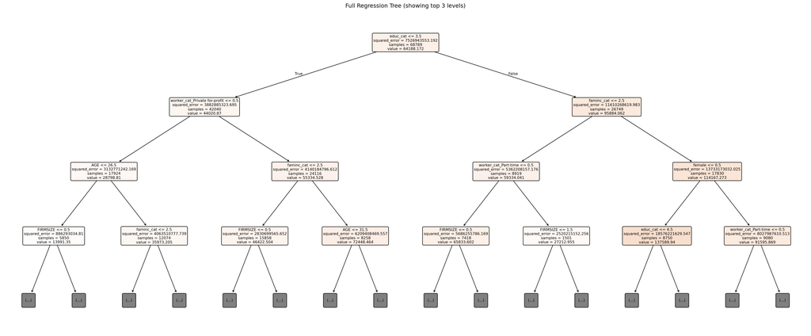

```python
full_tree_r = DecisionTreeRegressor(
    min_samples_split=20,
    min_samples_leaf=5,
    random_state=65
)
full_tree_r.fit(X_train_r, Y_train_r)

print(f"Number of leaves in full tree: {full_tree_r.get_n_leaves()}")
print(f"Depth of full tree: {full_tree_r.get_depth()}")

plt.figure(figsize=(24, 10))
plot_tree(
    full_tree_r,
    feature_names=reg_feature_cols,
    filled=True,
    rounded=True,
    max_depth=3,
    fontsize=8
)
plt.title("Full Regression Tree (showing top 3 levels)")
plt.tight_layout()
plt.show()
```

**c)** Use [`cost_complexity_pruning_path`](https://scikit-learn.org/stable/modules/generated/sklearn.tree.DecisionTreeRegressor.html#sklearn.tree.DecisionTreeRegressor.cost_complexity_pruning_path) to explore how `ccp_alpha` affects tree size. Plot the number of leaves as a function of `ccp_alpha`. Choose a `ccp_alpha` that produces a reasonably small tree.

```python
# Get the pruning path
path_r = full_tree_r.cost_complexity_pruning_path(X_train_r, Y_train_r)
ccp_alphas_r = path_r.ccp_alphas
ccp_alphas_r_pos = ccp_alphas_r[ccp_alphas_r > 0]
# Subsample ~25 log-spaced alpha values (fitting a tree for every alpha is too slow)
log_alphas_r = np.logspace(
    np.log10(ccp_alphas_r_pos.min()),
    np.log10(ccp_alphas_r_pos.max()),
    num=25
)
log_alphas_r = np.unique(np.concatenate(([0.0], log_alphas_r)))

# Compute number of leaves for each sampled alpha
n_leaves_r = []
for alpha in log_alphas_r:
    tree = DecisionTreeRegressor(
        min_samples_split=20,
        min_samples_leaf=5,
        ccp_alpha=alpha,
        random_state=65
    )
    tree.fit(X_train_r, Y_train_r)
    n_leaves_r.append(tree.get_n_leaves())

ccp_df_r = pd.DataFrame({'ccp_alpha': log_alphas_r, 'n_leaves': n_leaves_r})
print(ccp_df_r)
```

```
       ccp_alpha  n_leaves
0   0.000000e+00      5822
1   2.073530e+00      5821
2   4.681836e+00      5820
3   1.057114e+01      5819
4   2.386865e+01      5816
5   5.389317e+01      5807
6   1.216857e+02      5801
7   2.747549e+02      5780
8   6.203707e+02      5733
9   1.400739e+03      5669
10  3.162736e+03      5458
11  7.141161e+03      4927
12  1.612407e+04      4037
13  3.640663e+04      2861
14  8.220276e+04      1862
15  1.856061e+05      1188
16  4.190811e+05       744
17  9.462458e+05       335
18  2.136534e+06        82
19  4.824093e+06        39
20  1.089235e+07        24
21  2.459390e+07        14
22  5.553071e+07         6
23  1.253831e+08         4
24  2.831033e+08         2
25  6.392206e+08         1
```

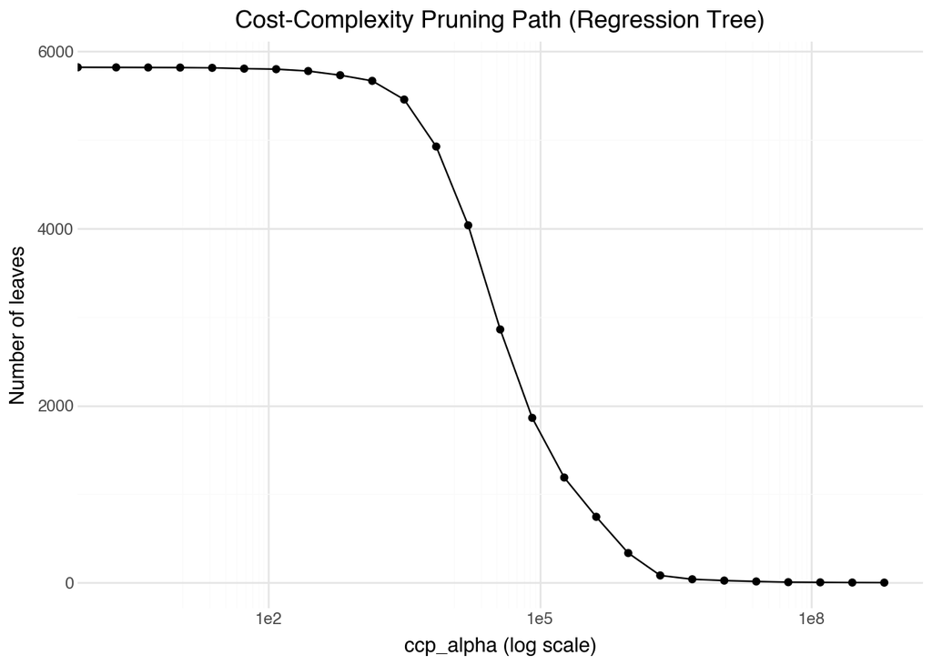

```python
# Plot number of leaves vs ccp_alpha
(
    ggplot(ccp_df_r, aes(x='ccp_alpha', y='n_leaves')) +
    geom_line() +
    geom_point() +
    scale_x_log10() +
    labs(
        title='Cost-Complexity Pruning Path (Regression Tree)',
        x='ccp_alpha (log scale)',
        y='Number of leaves'
    ) +
    theme_minimal()
)
```

```python
# Choose a ccp_alpha that gives a small, interpretable tree
optimal_ccp_alpha_r = 5.553071e+07
expected_leaves_r = int(
    ccp_df_r.loc[np.isclose(ccp_df_r['ccp_alpha'], optimal_ccp_alpha_r), 'n_leaves'].iloc[0]
)
print(f"Chosen ccp_alpha: {optimal_ccp_alpha_r}")
print(f"Expected number of leaves: {expected_leaves_r}")
```

```
Chosen ccp_alpha: 55530710.0
Expected number of leaves: 6
```

**d)** Fit a pruned regression tree with the optimal `ccp_alpha` and plot it. Compute the test RMSE ([`mean_squared_error`](https://scikit-learn.org/stable/modules/generated/sklearn.metrics.mean_squared_error.html)) and R-squared ([`r2_score`](https://scikit-learn.org/stable/modules/generated/sklearn.metrics.r2_score.html)).

```
Number of leaves in pruned tree: 6
Depth of pruned tree: 4

Test RMSE (pruned tree): $79,696.46
Test R-squared (pruned tree): 0.1685
```

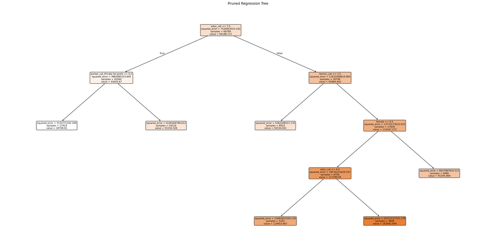

```python
pruned_tree_r = DecisionTreeRegressor(
    min_samples_split=20,
    min_samples_leaf=5,
    ccp_alpha=optimal_ccp_alpha_r,
    random_state=65
)
pruned_tree_r.fit(X_train_r, Y_train_r)

print(f"Number of leaves in pruned tree: {pruned_tree_r.get_n_leaves()}")
print(f"Depth of pruned tree: {pruned_tree_r.get_depth()}")

# Test performance
y_pred_r = pruned_tree_r.predict(X_test_r)
test_rmse_tree = np.sqrt(mean_squared_error(Y_test_r, y_pred_r))
test_r2_tree = r2_score(Y_test_r, y_pred_r)
print(f"\nTest RMSE (pruned tree): ${test_rmse_tree:,.2f}")
print(f"Test R-squared (pruned tree): {test_r2_tree:.4f}")

plt.figure(figsize=(24, 12))
plot_tree(
    pruned_tree_r,
    feature_names=reg_feature_cols,
    filled=True,
    rounded=True,
    fontsize=8
)
plt.title("Pruned Regression Tree")
plt.tight_layout()
plt.show()
```

### Question 4: Regression Random Forest

**a)** Tune the [`RandomForestRegressor`](https://scikit-learn.org/stable/modules/generated/sklearn.ensemble.RandomForestRegressor.html) by trying a few values of `max_features` and `min_samples_leaf` using OOB R-squared. Use `n_estimators=200`, `oob_score=True`, and `random_state=65`. Report the best parameters, then fit the best model with `n_estimators=500` and report OOB R-squared, test RMSE, and test R-squared. How does it compare to the pruned regression tree?

*Hint: Try `max_features` in `['sqrt', 1/3, 0.5]` (corresponding to sqrt(p), p/3, and p/2 features per split) and `min_samples_leaf` in `[1, 5, 10]`.*

```python
# Tune over a small grid using OOB score
results_r = []
for mf in ['sqrt', 1/3, 0.5]:
    for msl in [1, 5, 10]:
        rf = RandomForestRegressor(
            n_estimators=200,
            oob_score=True,
            random_state=65,
            max_features=mf,
            min_samples_leaf=msl
        )
        rf.fit(X_train_r, Y_train_r)
        results_r.append({
            'max_features': mf, 'min_samples_leaf': msl,
            'oob_r2': rf.oob_score_
        })

tune_df_r = pd.DataFrame(results_r).sort_values('oob_r2', ascending=False)
print(tune_df_r.to_string(index=False))
```

```
max_features  min_samples_leaf   oob_r2
        sqrt                10 0.250688
    0.333333                10 0.249883
        sqrt                 5 0.245313
         0.5                10 0.245084
    0.333333                 5 0.242149
         0.5                 5 0.234751
        sqrt                 1 0.097694
    0.333333                 1 0.091748
         0.5                 1 0.084688
```

```python
# Fit the best model with n_estimators=500
best_r = tune_df_r.iloc[0]
print(f"Best parameters: max_features={best_r['max_features']}, min_samples_leaf={best_r['min_samples_leaf']}")

rf_reg = RandomForestRegressor(
    n_estimators=500,
    oob_score=True,
    random_state=65,
    max_features=best_r['max_features'],
    min_samples_leaf=int(best_r['min_samples_leaf'])
)
rf_reg.fit(X_train_r, Y_train_r)

y_pred_rf_r = rf_reg.predict(X_test_r)
rf_test_rmse = np.sqrt(mean_squared_error(Y_test_r, y_pred_rf_r))
rf_test_r2 = r2_score(Y_test_r, y_pred_rf_r)
rf_oob_r2 = rf_reg.oob_score_

print(f"\nRandom Forest OOB R-squared: {rf_oob_r2}")
print(f"Random Forest test RMSE: ${rf_test_rmse:,.2f}")
print(f"Random Forest test R-squared: {rf_test_r2}")
```

```
Best parameters: max_features=sqrt, min_samples_leaf=10

Random Forest OOB R-squared: 0.25104775376226807
Random Forest test RMSE: $75,052.44
Random Forest test R-squared: 0.2625585050834851
```

**b)** Generate a feature importance plot. Which are the top 3 most important predictors of wage income? Do these make substantive sense?

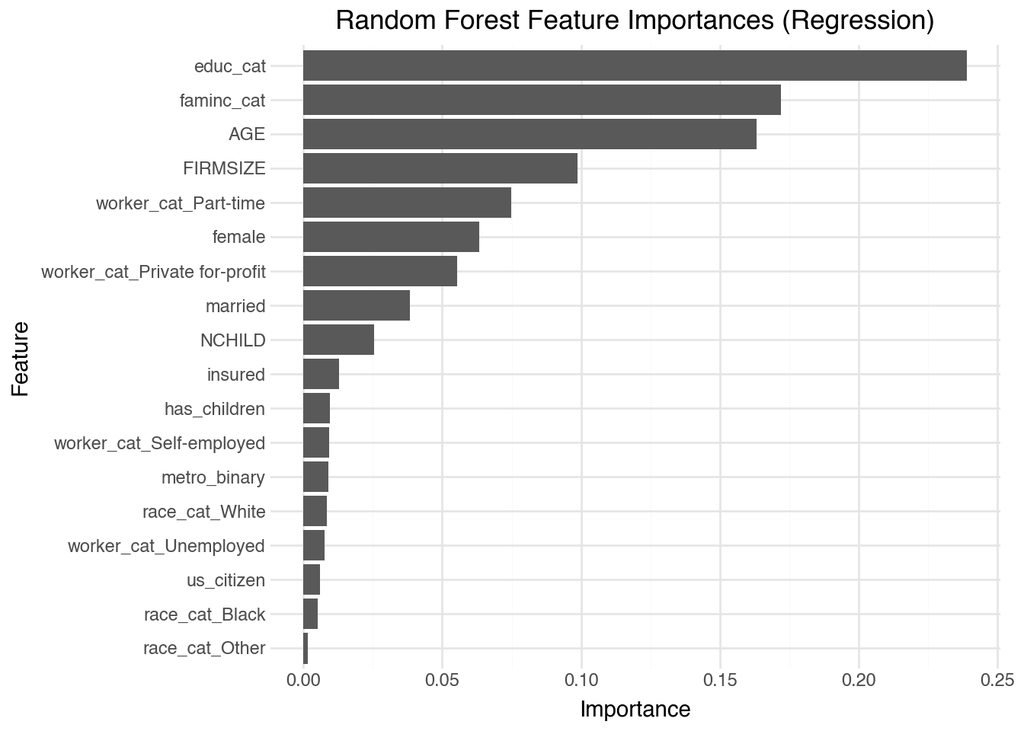

```python
rf_importances_r = rf_reg.feature_importances_

imp_df_r = pd.DataFrame({
    'feature': reg_feature_cols,
    'importance': rf_importances_r
}).sort_values('importance')
imp_df_r['feature'] = pd.Categorical(imp_df_r['feature'], categories=imp_df_r['feature'])

(
    ggplot(imp_df_r, aes(x='feature', y='importance')) +
    geom_col() +
    coord_flip() +
    labs(
        title='Random Forest Feature Importances (Regression)',
        x='Feature',
        y='Importance'
    ) +
    theme_minimal()
)
```

**Summary:**

According to the feature importance plot, the top 3 most important features are `educ_cat`, `faminc_cat`, and `AGE`. These features make substantive sense because they are all related to the worker’s income.

**c)** Create a summary table comparing the pruned regression tree and random forest on test RMSE and R-squared. Briefly discuss which model you would recommend and why.

```python
comparison_r = pd.DataFrame({
    'Model': ['Pruned Regression Tree', 'Random Forest'],
    'Test RMSE': [test_rmse_tree, rf_test_rmse],
    'Test R-squared': [test_r2_tree, rf_test_r2]
})
print(comparison_r.to_string(index=False))
```

```
                 Model    Test RMSE  Test R-squared
Pruned Regression Tree 79696.464012        0.168474
         Random Forest 75052.435842        0.262559
```

**Summary:**

I would recommend the random forest because it has a higher test R-squared and lower test RMSE. This means that the random forest is able to capture more variance in the data and is able to generalize better to unseen data.